# Module Project

220225605

2023-05-15

# PSY6422 Data Management and Visualisation

## Data Origins and Summary

### Background

Previous research has indicated that large-scale consumption of meat and animal-based proteins has deleterious effects on the environment. Its consumption has also been linked to certain lifestyle diseases. In response to these challenges, consumers have started adopting sustainable diets - diets that include plant based and alternative proteins. In spite of the supposed benefits of such a diet, some consumers are resistant to any changes in their meat-eating habits.

### Data Origins

The raw data constituted information procured through a survey undertaken by the Food Standards Agency, United Kingdom. The ‘Alternative Proteins Consumer Survey’ can be accessed [here](https://data.food.gov.uk/catalog/datasets/4353459f-a369-44e1-b4d0-8d06a1ccc479). This survey was conducted to understand consumer’s awareness and perception of alternative and novel proteins. 1,930 respondents between the ages of 16 and 75 living in England, Wales and Northern Ireland participated in the survey. Data was collected between 9th – 11th December 2021 via Ipsos MORI’s online omnibus.  
Participants were asked a variety of questions resulting in a broad range of variables. These include – gender, age group, region, household size, presence of children, education, marital status, household income, ethnicity, working status, social grade, awareness of alternative/novel proteins, perceived safety of consumption of alternative/novel proteins and willingness to consume alternative/novel proteins. For the purpose of this visualisation, only those variables representing region and willingness to consume alternative/novel proteins will be utilised.

### Summary

Consumers’ willingness to consume novel meat substitutes or plant based ‘alternative’ proteins is influenced by a variety of factors, including familiarity, attitudes, food neophobia, disgust and social norms (Onwezen et al., 2021). Individuals belonging to certain regions are likely to have similar attitudes towards certain types of food. My final project will seek to demonstrate how willingness to consume alternative proteins differs across the various regions of England and Wales. A choropleth will be used to visualise how willingness to consume alternative proteins differs across the region.

```r
# load data and required packages
# ensure that package "here" is installed first using install.packages("here")
library(here)
# ensure that package "tidyverse" is installed first using install.packages("tidyverse")
library(tidyverse)
data_org <- read_csv(here("data", "AltProt.csv")) # loading the required data
head(data_org) # inspecting the first few lines of the loaded data
```

```
## # A tibble: 6 × 167
##   DMQ_RESP_GEN…¹ DMQ_R…² DMQ_R…³ DMQ_H…⁴ DMQ_K…⁵ DMQ_U…⁶ DMQ_U…⁷ DMQ_U…⁸ DMQ_U…⁹
##            <dbl>   <dbl>   <dbl>   <dbl>   <dbl>   <dbl>   <dbl>   <dbl>   <dbl>
## 1              2       2       5       3       1       5       3       4       2
## 2              2       1      10       3       0       5       1       3       2
## 3              2       2       9       3       2       6       3       5       2
## 4              1       3       4       6       4       2       3       5       2
## 5              2       3       2       6       3       3       3       4       2
## 6              2       4       8       1       0       3       1       6       2
## # … with 158 more variables: DMQ_EMP01 <dbl>, DMQ_EMP01_RECODED <dbl>,
## #   UK01SG <dbl>, DMQ_UK01SG_RECODED <dbl>, Q2089090438Edibleinsects <dbl>,
## #   Q2089090438Labgrownmeatsometimesreferredtoasculturedmeatorcu <dbl>,
## #   Q2089090438Plantbasedproteins <dbl>, Q2011120850 <dbl>, Q2055782931 <dbl>,
## #   Q2021612575 <dbl>,
## #   Q2018263715Labgrownmeatsometimesreferredtoasculturedmeatorcu <dbl>,
## #   Q2018263715Edibleinsectsegmealwormsgrasshoppers <dbl>, …
```

## Data Preparation

In order to tidy the original dataset, I reduced the number of columns by selecting only those that reported on composite dimension scores. Furthermore, I dropped any rows that contained missing values.After this, to improve interpretability, I renamed columns. I also decided to create three more columns by totalling scores received by participants on each subdimension.

```r
# removing unwanted columns and rows with missing values
data_tidy <- data_org %>% select(-c(23:162)) %>% drop_na()

# renaming columns and creating more columns
data_tidy <- data_tidy %>%
  rename(
    "gender" = "DMQ_RESP_GENDER",
    "age_grp" = "DMQ_RESP_AGE_RECODED",
    "region" = "DMQ_REGION",
    "house_size" = "DMQ_HHCMP10",
    "kids" = "DMQ_KIDS02",
    "edu" = "DMQ_UK02EDU",
    "marital_stat" = "DMQ_UK01MAR",
    "income" = "DMQ_UK02INC",
    "ethnicity" = "DMQ_UK02ETH",
    "work_stat" = "DMQ_EMP01",
    "soc_grade" = "DMQ_UK01SG_RECODED",
    "awareness_insect" = "Q2089090438Edibleinsects",
    "awareness_labmeat" = "Q2089090438Labgrownmeatsometimesreferredtoasculturedmeatorcu",
    "awareness_plprot" = "Q2089090438Plantbasedproteins",
    "safety_plprot" = "Q2011120850",
    "safety_insect" = "Q2055782931",
    "safety_labmeat" = "Q2021612575",
    "willingness_labmeat" =
      "Q2018263715Labgrownmeatsometimesreferredtoasculturedmeatorcu",
    "willingness_insect" =
      "Q2018263715Edibleinsectsegmealwormsgrasshoppers",
    "willingness_plprot" =
      "Q2018263715Plantbasedproteinsegsoyhempseedquinoa",
    "replacement_ground" =
      "Q2079418049Groundintoafoodforaddedproteinegbreadburgersfalaf",
    "replacement_sweet" =
      "Q2079418049Madeintosweetsorjellies",
    "replacement_beverage" =
      "Q2079418049Madeintobeveragesegsportsdrinksproteinshakes",
    "replacement_meal" =
      "Q2079418049Amealorproteinreplacement")%>%
  mutate(tot_aware = awareness_insect+awareness_labmeat+awareness_plprot) %>%
  mutate(tot_safety = safety_plprot+safety_insect+safety_labmeat) %>%
  mutate(tot_willingness = willingness_labmeat+willingness_insect+willingness_plprot)
```

Numeric columns were then converted to columns containing factors. Information about participants from Northern Ireland was removed because shapefiles containing the geographic information of Northern Ireland was not found. This process of data preparation may seem superfluous because all the variables are not being used for this visualisation; however, the tidied data could be useful for future analyses and visualisations.

```r
# converting numeric variables to factor variables

# gender
data_tidy$gender <- cut(
  data_tidy$gender, 2, labels = c(
    'Male',
    'Female'))
# age group
data_tidy$age_grp <-  cut(
  data_tidy$age_grp, 6, labels = c(
    '16-24',
    '25-34',
    '35-44',
    '45-54',
    '55-64',
    '65-75'))
# region
data_tidy <- subset(data_tidy, region < 11)
data_tidy$region <- cut(
  data_tidy$region, 10, labels = c(
    'North East',
    'North West',
    'Yorkshire and The Humber',
    'West Midlands',
    'East Midlands',
    'East of England',
    'South West',
    'South East',
    'London',
    'Wales'))
# education
data_tidy$edu <- cut(
  data_tidy$edu, 7, labels = c(
    'Primary school',
    'Secondary school (age under 15 years old)',
    'GNVQ / GSVQ / GCSE/ SCE standard',
    'NVQ1, NVQ2',
    'NVQ3/ SCE Higher Grade/ Advanced GNVQ/ GCE A/AS or similar',
    'NVQ4 / HNC / HND / Bachelors degree or similar',
    'NVQ5 or post-graduate diploma'))
# income
data_tidy$income <- cut(
  data_tidy$income, 11, labels = c(
    'Under £5,000',
    '£5,000 - 9,999',
    '£10,000 - 14,999',
    '£15,000 - 19,999',
    '£20,000 - 24,999',
    '£25,000 - 34,999',
    '£35,000 - 44,999',
    '£45,000 - 54,999',
    '£55,000 - 99,999',
    '£100,000 or more',
    'Prefer not to answer'))
# ethnicity
data_tidy$ethnicity <- cut(
  data_tidy$ethnicity, 24, labels = c(
    'White', 'White', 'White', 'White', 'White',
    'Mixed or multiple ethnic groups','Mixed or multiple ethnic groups', 'Mixed or multiple ethnic groups',  'Mixed or multiple ethnic groups', 'Mixed or multiple ethnic groups',
    'Asian or Asian British', 'Asian or Asian British', 'Asian or Asian British', 'Asian or Asian British', 'Asian or Asian British','Asian or Asian British',
    'Black, Black British, Caribbean or African', 'Black, Black British, Caribbean or African', 'Black, Black British, Caribbean or African', 'Black, Black British, Caribbean or African',
    'Other ethnic group', 'Other ethnic group', 'Other ethnic group', 'Other ethnic group'))

# viewing the first few rows of the tidied data set
head(data_tidy)
```

```
## # A tibble: 6 × 30
##   gender age_grp region       house…¹  kids edu   marit…² income ethni…³ work_…⁴
##   <fct>  <fct>   <fct>          <dbl> <dbl> <fct>   <dbl> <fct>  <fct>     <dbl>
## 1 Female 25-34   East Midlan…       3     1 NVQ3…       3 £15,0… White         6
## 2 Female 16-24   Wales              3     0 NVQ3…       1 £10,0… White         2
## 3 Female 25-34   London             3     2 NVQ4…       3 £20,0… White         1
## 4 Male   35-44   West Midlan…       6     4 Seco…       3 £20,0… White         1
## 5 Female 35-44   North West         6     3 GNVQ…       3 £15,0… White         6
## 6 Female 45-54   South East         1     0 GNVQ…       1 £25,0… White         2
## # … with 20 more variables: DMQ_EMP01_RECODED <dbl>, UK01SG <dbl>,
## #   soc_grade <dbl>, awareness_insect <dbl>, awareness_labmeat <dbl>,
## #   awareness_plprot <dbl>, safety_plprot <dbl>, safety_insect <dbl>,
## #   safety_labmeat <dbl>, willingness_labmeat <dbl>, willingness_insect <dbl>,
## #   willingness_plprot <dbl>, replacement_ground <dbl>,
## #   replacement_sweet <dbl>, replacement_beverage <dbl>,
## #   replacement_meal <dbl>, DPWeight <dbl>, tot_aware <dbl>, …
```

```r
# saving the tidied data
save(data_tidy, file = here("processed data", "tidy_data.Rdata"))
# creating a new data-frame containing variables that would be used for this visualisation

data_tidy_viz <- data_tidy %>% select(c("region", "tot_willingness"))
```

## Data Visualisation

To visualise overall differences in willingness to consume alternative proteins across regions, I first needed to load a geospatial object containing information about region boundaries. The shapefile can be downloaded from the [UK Data Service Website](https://borders.ukdataservice.ac.uk/bds.html). I downloaded ‘England and Wales Regions, 2022’ for the regions of England and Wales.. Before loading the shapefile, it is essential to install and load the package ‘rgdal’.

```r
# loading the shapefile
# install.packages("rgdal")
library(rgdal)
shp <- readOGR(here("data","Ew_rgn_2022_bgc/ew_rgn_2022_bgc.shp"))
# converting the shapefile into a dataframe
shpfort <- fortify(shp, region = "name")
# renaming variables in the fortified shapefile
shp_new <- rename(shpfort, "region" = "id")
```

After the information about the boundaries of the region has been loaded, the data-set containing the variable that needs to be visualised must be merged with the fortified shapefile.

```r
# merge
shp_merge <- shp_new %>% left_join(data_tidy_viz, by = c('region'), multiple = "all")
# reordering the merged data-set
shp_merge <- arrange(shp_merge, order)
```

The next step is to make a basic choropleth with the default settings.

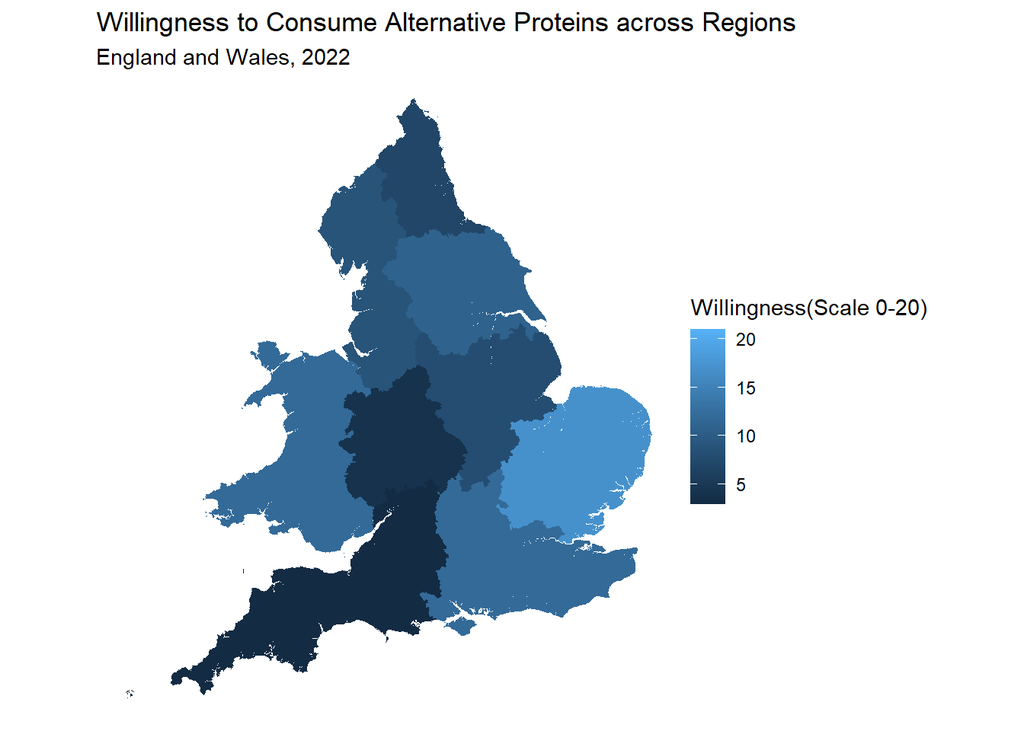

```r
# choropleth with dafault arguments
p <- ggplot(data = shp_merge, aes(x = long, y = lat, group = group, fill = tot_willingness), alpha = 0.9)
p + geom_polygon() + coord_equal() + theme_void() +
  ggtitle('Willingness to Consume Alternative Proteins across Regions',
          subtitle = 'England and Wales, 2022')+labs(fill="Willingness(Scale 0-20)")
```

We can now customise the choropleth.

```r
# choropleth with custom arguments
library(viridis)
```

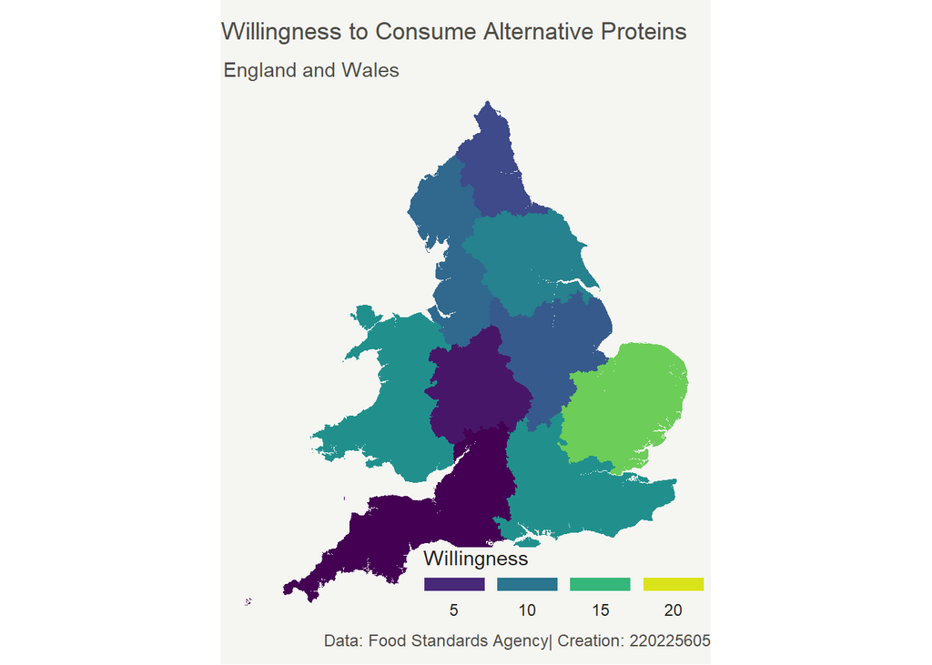

```r
p +
  geom_polygon() +
  coord_equal() +
  theme_void()  +
  scale_fill_viridis(name="Willingness", guide = guide_legend( keyheight = unit(3, units = "mm"), keywidth=unit(12, units = "mm"), label.position = "bottom", title.position = 'top', nrow=1) ) +
  labs(
    title = "Willingness to Consume Alternative Proteins",
    subtitle = "England and Wales",
    caption = "Data: Food Standards Agency| Creation: 220225605"
  ) +
  theme(
    text = element_text(color = "#22211d"),
    plot.background = element_rect(fill = "#f5f5f2", color = NA),
    panel.background = element_rect(fill = "#f5f5f2", color = NA),
    legend.background = element_rect(fill = "#f5f5f2", color = NA),

    plot.title = element_text(size= 13, hjust=0.01, color = "#4e4d47", margin = margin(b = -0.1, t = 0.4, l = 2, unit = "cm")),
    plot.subtitle = element_text(size= 11, hjust=0.01, color = "#4e4d47", margin = margin(b = -0.1, t = 0.43, l = 2, unit = "cm")),
    plot.caption = element_text( size= 9, color = "#4e4d47", margin = margin(b = 0.3, r=-99, unit = "cm") ),
    legend.position = c(0.7, 0.09))
```

## Save

Saving the customised choropleth.

```r
ggsave(here("plots", "myfinalgraph.png"), width = 14, height = 18, units = "cm")
```

## Discussion

```r
table(data_tidy$region, data_tidy$ethnicity)
```

```
##
##                            White Mixed or multiple ethnic groups
##   North East                  72                               1
##   North West                 202                              12
##   Yorkshire and The Humber   167                               4
##   West Midlands              150                               5
##   East Midlands              143                               3
##   East of England            165                               4
##   South West                 159                               3
##   South East                 244                               7
##   London                     172                              18
##   Wales                      100                               3
##
##                            Asian or Asian British
##   North East                                    1
##   North West                                   14
##   Yorkshire and The Humber                      7
##   West Midlands                                14
##   East Midlands                                 5
##   East of England                               5
##   South West                                    8
##   South East                                   13
##   London                                       40
##   Wales                                         1
##
##                            Black, Black British, Caribbean or African
##   North East                                                        1
##   North West                                                        2
##   Yorkshire and The Humber                                          1
##   West Midlands                                                     6
##   East Midlands                                                     6
##   East of England                                                   1
##   South West                                                        2
##   South East                                                        5
##   London                                                           30
##   Wales                                                             2
##
##                            Other ethnic group
##   North East                                1
##   North West                                2
##   Yorkshire and The Humber                  1
##   West Midlands                             3
##   East Midlands                             2
##   East of England                           6
##   South West                                3
##   South East                                2
##   London                                   11
##   Wales                                     1
```

## Extensions

Although I am pleased with what I have produced, if I had more time, I would have attempted to build on my choropleth. For example, I would have visualised a bubble map, highlighting ethnically diverse areas. I would have also produced a bivariate choropleth, visualising both perceived safety and willingness to consume alternative proteins across regions in England and Wales.

## References

Onwezen, M. C., Bouwman, E. P., Reinders, M. J., & Dagevos, H. (2021). A systematic review on consumer acceptance of alternative proteins: Pulses, algae, insects, plant-based meat alternatives, and cultured meat. Appetite, 159, 105058. https://doi.org/10.1016/j.appet.2020.105058